# Industrial Survey

Arturo Torre

23/10/2018

## Mexican Industrial Survey

### Intro

```r
#We load the data imported directly from INEGI´s website.
datos <- read.csv(file="datos.csv", header=TRUE, sep=",")
```

It is important to mention that we have aggregated variables by sector and subsector.

We will follow Hadley Wickham´s tidy data format mainly by subsetting particular data from the survey´s raw data.

### General Industrial Manufacturing

```r
manuf <- datos %>% select(CODIGO_SCIAN, ANIO, H010B, H010C) %>% filter(CODIGO_SCIAN %in% c("31-33"))
```

In this section we will analyse the general overview of industrial manufacturing in Mexico.

```r
#For easy handing we must use the tidy data paradigm
manuf_tidy <- manuf %>% gather(Genero,Numero,H010B:H010C)
manuf_tidy$Genero[manuf_tidy$Genero == "H010B"] <- "Hombres"
manuf_tidy$Genero[manuf_tidy$Genero == "H010C"] <- "Mujeres"
```

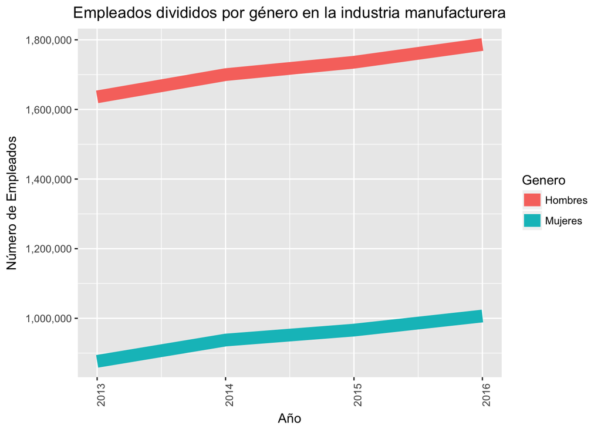

```r
manuf1
```

```r
manuf_ins <- datos %>% select(CODIGO_SCIAN, ANIO, K316B, K316C) %>% filter(CODIGO_SCIAN %in% c("31-33"))
```

```r
#For easy handing we must use the tidy data paradigm
manuf_tidy <- manuf_ins %>% gather(Origen, Cantidad, K316B:K316C)
manuf_tidy$Origen[manuf_tidy$Origen == "K316B"] <- "Nacional"
manuf_tidy$Origen[manuf_tidy$Origen == "K316C"] <- "Importado"
```

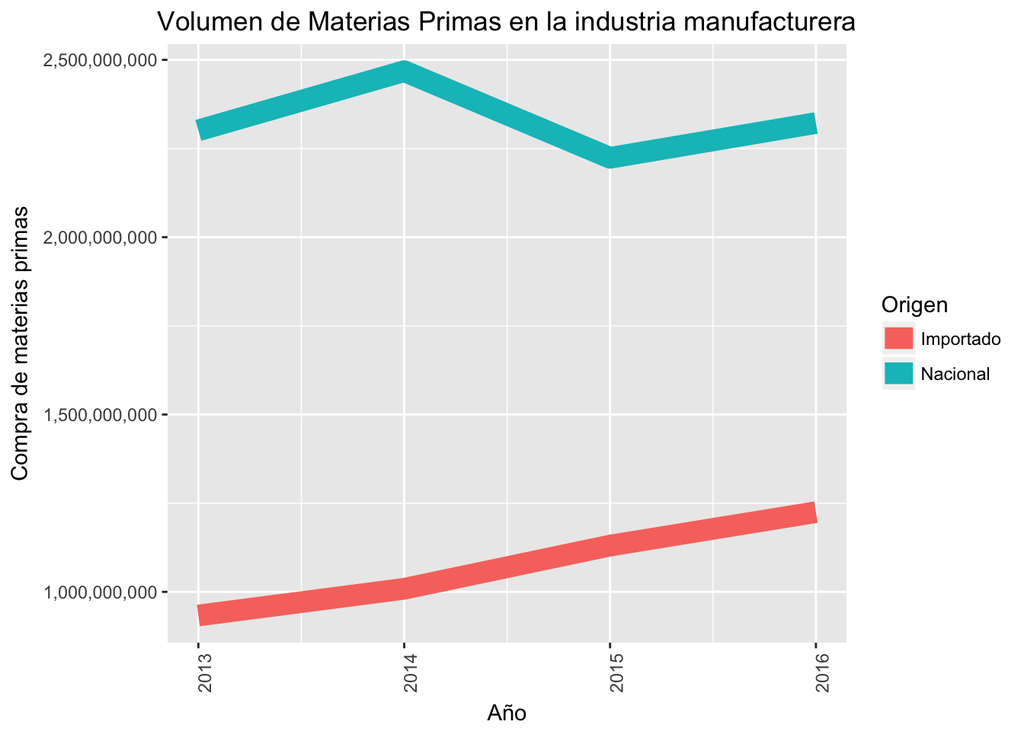

```r
manuf2
```

```r
manuf_vtas <- datos %>% select(CODIGO_SCIAN, ANIO, M310B, M310C) %>% filter(CODIGO_SCIAN %in% c("31-33"))
```

```r
#For easy handing we must use the tidy data paradigm
manuf_tidy <- manuf_vtas %>% gather(Destino, Ventas, M310B:M310C)
manuf_tidy$Destino[manuf_tidy$Destino == "M310B"] <- "Nacional"
manuf_tidy$Destino[manuf_tidy$Destino == "M310C"] <- "Exportación"
```

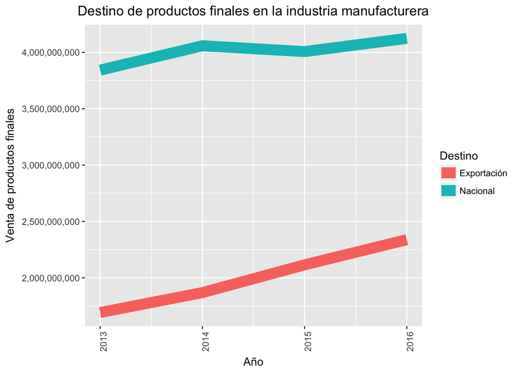

```r
manuf3
```

At 6 figure level we 240 different industries.

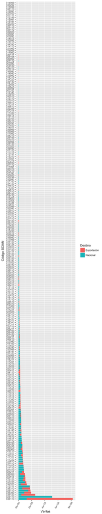

```r
g
```

Lets make a deeper analysis in on heavy industry(defined by the Ministry of Economy as industries classified from 333 to 336) which are key in Mexican domestic industry.

### Automotive

In this section we will analyse the automotive industry in Mexico.

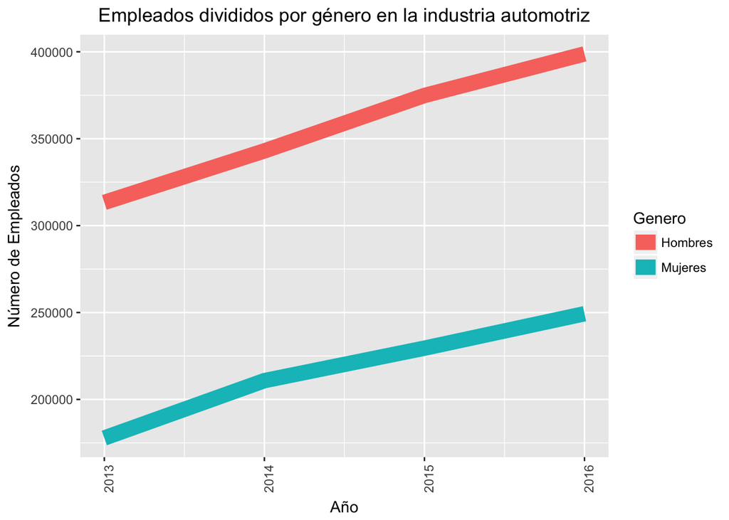

```r
auto1
```

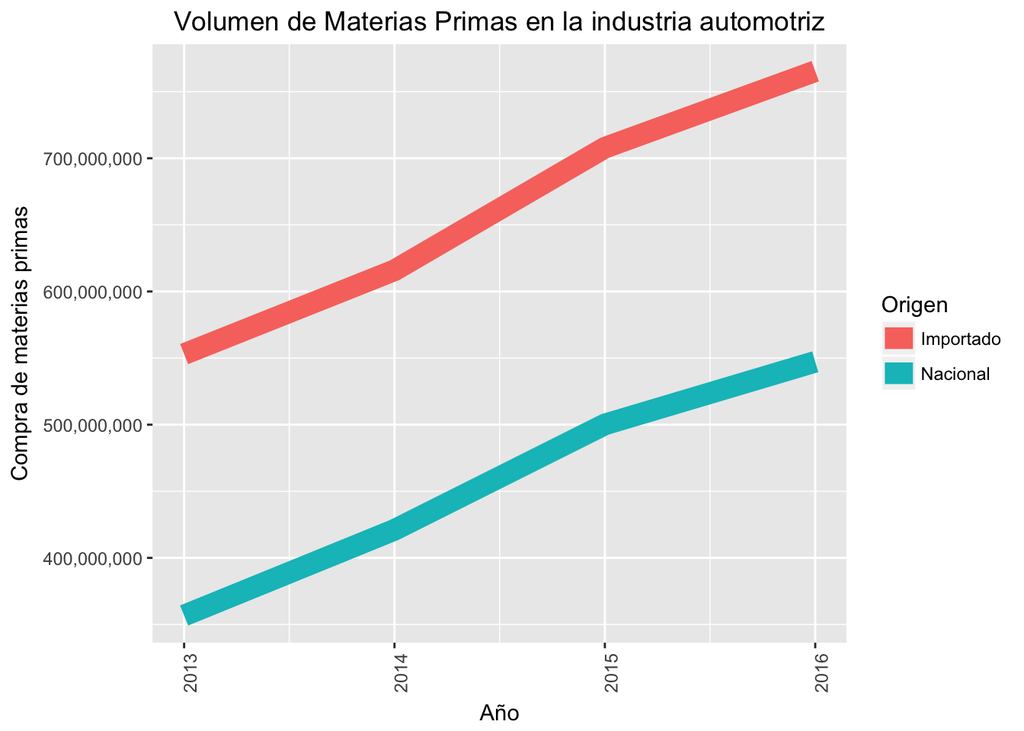

```r
auto2
```

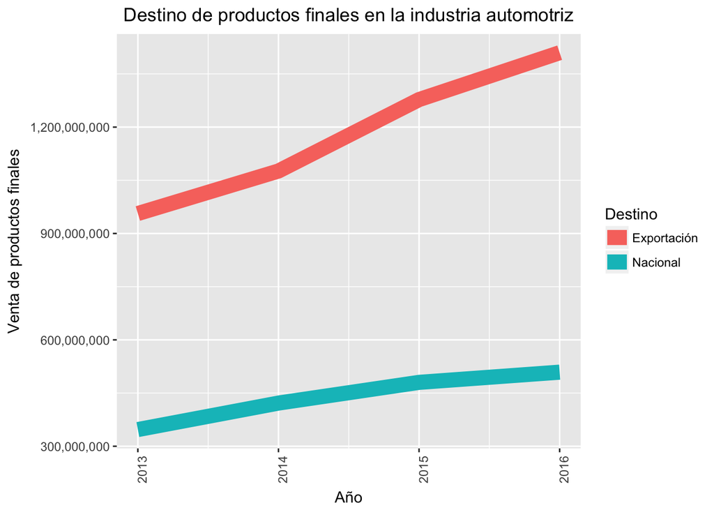

```r
auto3
```

### Electrical Equipment(including household appliances)

In this section we will analyse the electrical manufacturing industry in Mexico.

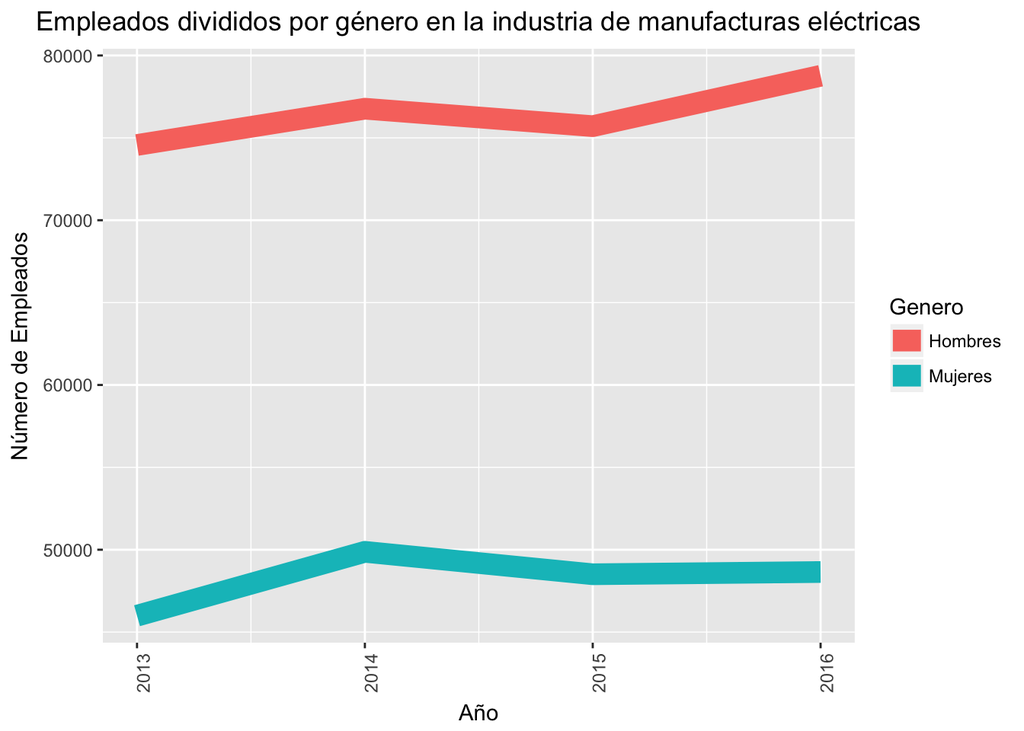

```r
electrical1
```

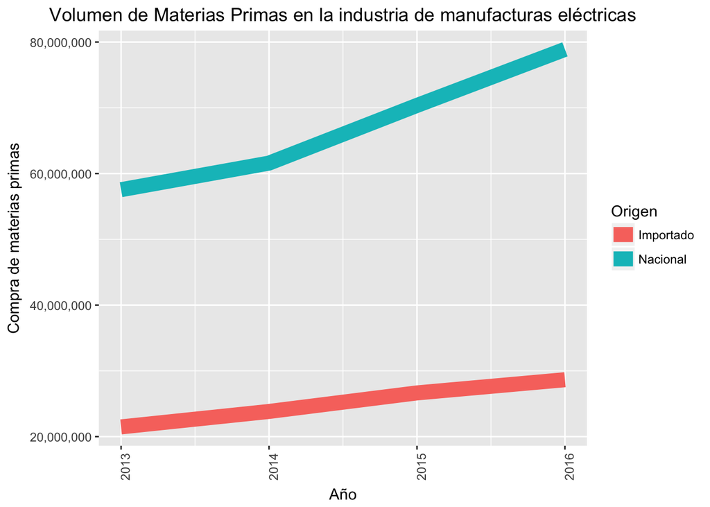

```r
electrical2
```

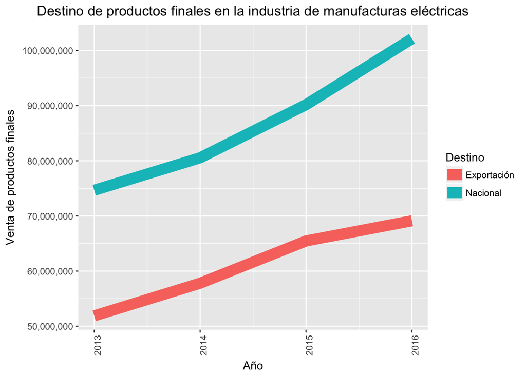

```r
electrical3
```

Despite its high international competitiveness this industry heavily relies on domestic market sales.

### Electronics

In this section we will analyse the electronics manufacturing industry in Mexico.

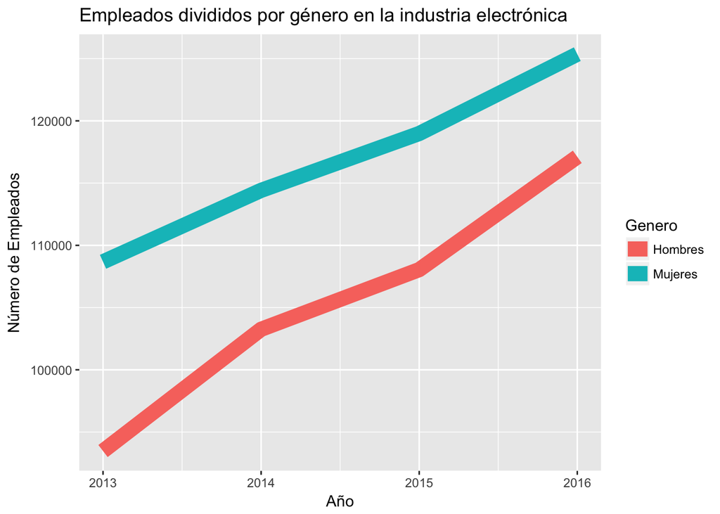

```r
electronics1
```

Not surprinsingly consisten with many studies, women dominate the electronics labor market due to its quality during the manufacturing process.

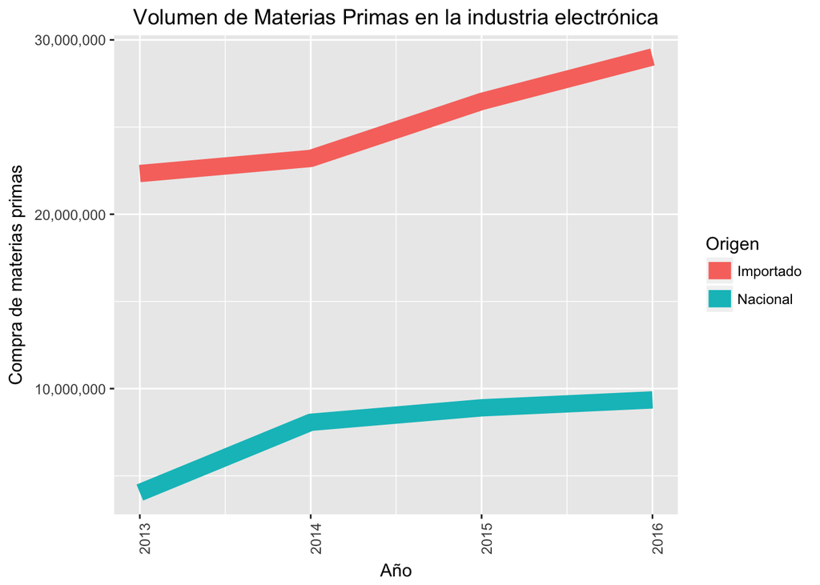

```r
electronics2
```

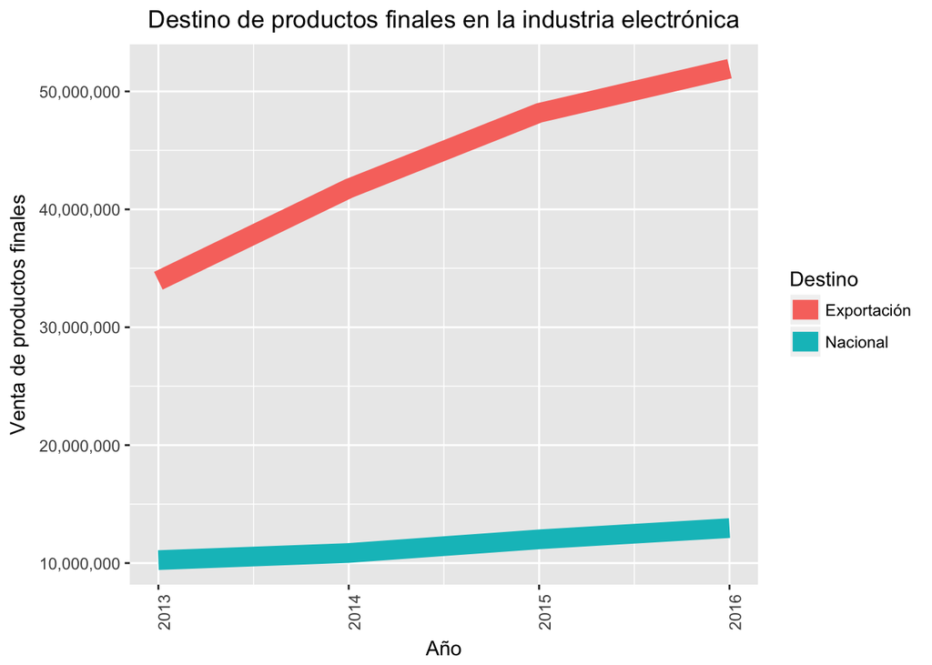

```r
electronics3
```

### Capital Goods

```r
cg <- datos %>% select(CODIGO_SCIAN, ANIO, H010B, H010C) %>% filter(CODIGO_SCIAN %in% c("333"))
```

In this section we will analyse the capital goods manufacturing industry in Mexico.

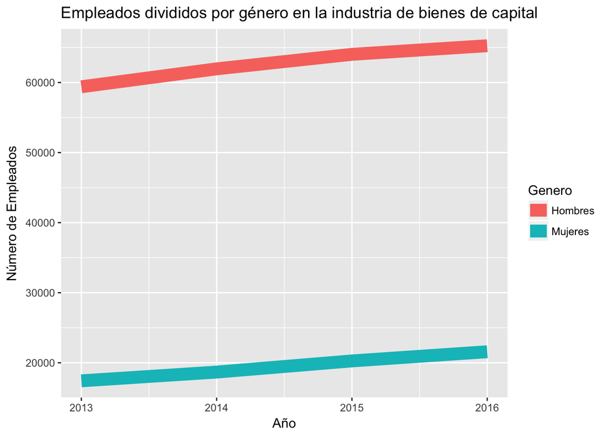

```r
cg1
```

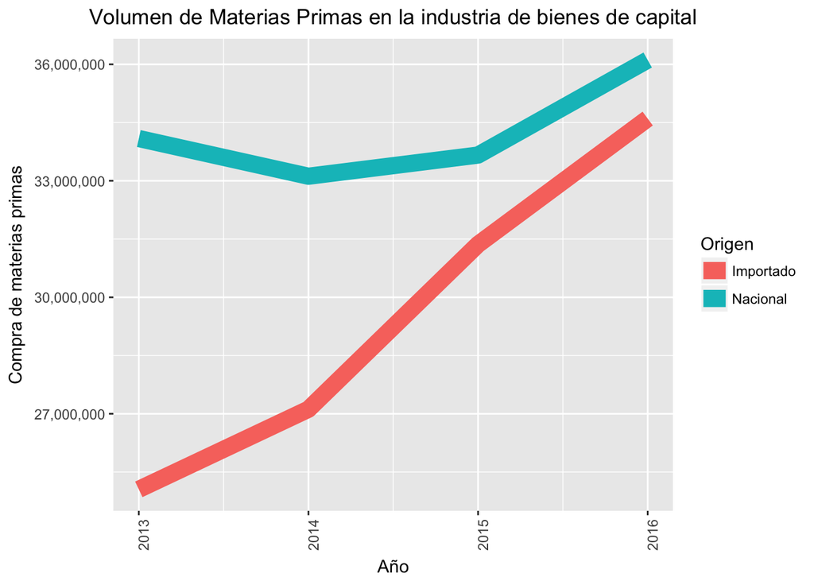

```r
cg2
```

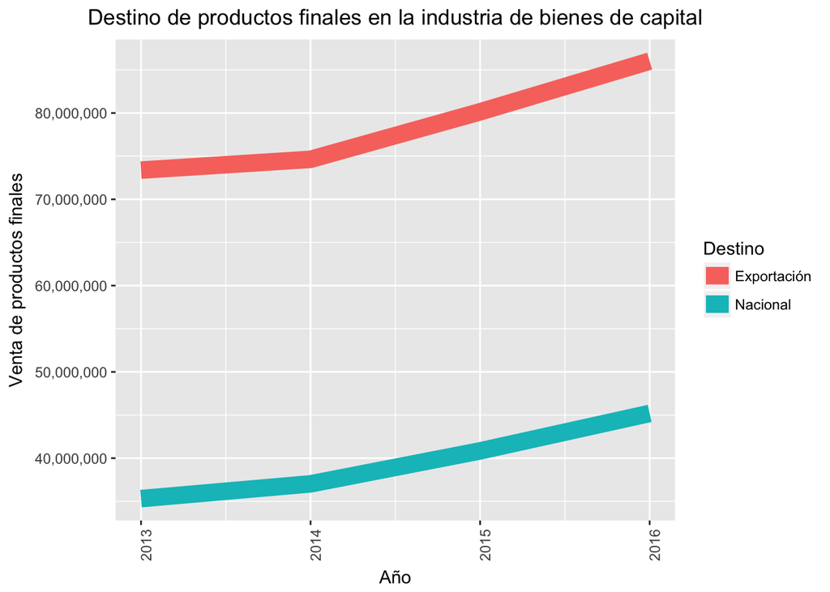

```r
cg3
```

### Findings

2.- Most employees are male, however electronics industry relies on female employees.

4.- Total indsutry has a different pattern. It relies on domestic markets for supplying. The biggest share of sales are in the domestic market and most employees are men.